# Week 5: Wrangling and Data Verbs

Data Computing Chapter 7

Presenter- Olivia Beck

Content Credit- Dr. Matthew Beckman

Sep 21 2022

## Agenda

- Introduce some software and commands that …
  - make it easy to access data tables and see how they are structured
    - For example: `data()`, `View()`, `help()`,
    - (more coming in Chapter 10)
  - learn about data verbs
  - implement two important data verbs: `group_by()` and `summarise()`

## Three Important Concepts

1. Data can be usefully organized into tables with “cases” and “variables.”
   - In “tidy data” every case is the same sort of thing (e.g. a person, a car, a year, a country in a year)
   - We sometimes even modify data in order to change what the cases represent in order to better represent a point.
2. Data graphics and “glyph-ready” data
   - each case corresponds to a “glyph” (mark) on the graph
   - each variable to a graphical attribute of that glyph such as x- or y-position, color, size, length, shape, etc.
   - same is true for more technical tools (e.g., models, predictions, etc.)
3. When data are not yet in glyph-ready form, you can transform (i.e. wrangle) them into glyph-ready form.
   - Such transformations are accomplished by performing one or more of a small set of basic operations on data tables
   - This is the work of data “verbs”

## Learning about the raw data

There are lots of ways to load data into your environment

- Most real data sources will require you to
  - read a file (e.g., CSV)
  - query a database (e.g., SQL)
  - configure an API
  - scrape from the web
- For convenience, many STAT 184 data sets are accessed from R packages or CSV files
- When acquiring data, it’s very important to pause and think about data provenance/origins
  - What might be useful to learn?
  - How is this accomplished?
  - Why does it matter?

## Recall: Key goals of a careful Exploratory Data Analysis?

1. **Examine the data source:** variable types, coding, missingness, summary statistics/plots, who/what/when/where/why/how data were collected
2. **Discover features that influence may modeling decisions:** investigate potential outliers, consideration for recoding variables (e.g., numeric data that’s functionally dichotomous), evaluate correlation structure (e.g., autocorrelation, hierarchy, spatial/temporal proximity)
3. **Address research questions:** build intuition and note preliminary observations/conclusions related to each research question. Also, note observations that prompt you to refine your research questions or add new questions to investigate

#### A few simple commands to help us “Examine the data source”:

- *Note:* often you need to examine information sources outside R to do a thorough examination.
- `help()` or `?`: if your data are part of an R package, this opens a help window with details about the data
- `data()`: if your data are part of an R package, this function loads the data set into your R environment and binds an object name
- `head(Dat)`: inspect the first few rows of `Dat`
- `View(Dat)`: opens a spreadsheet tab in RStudio showing `Dat` in it’s entirety
  - You can also click on the table name in the “Enviornment” Pane
  - Bad form to call `View()` in the Rmd, use the console for this one.
  - `head()` is best in the Rmd

## Guided practice

- `Minneapolis2013` data set in the `dcData` package
  - To do this, we need to download the package from GitHub

```r
# Upload data from course-materials
Minneapolis2013 <- read_csv("course-materials/class-notes/week-07/Minneapolis2013.csv")
```

[output not shown]

### Discussion questions:

1. What is the setting for the data?
   - What are they about?
   - Who collected them?
   - Why were they collected?
   - etc
2. How many cases are there?
3. In your own words, what kind of thing do the cases represent?
4. How many variables are there? What are their names?
5. Pick out three of the variables and say whether
   - the variable is quantitative or categorical
   - if categorical (R calls this a “factor”), what are some levels of the variable
   - if quantitative, what are the units of measurement of the variable.

Click [here](https://en.wikipedia.org/wiki/Instant-runoff_voting) to learn about rank choice voting (also called instant run off voting).

## Why we wrangle

Consider the Minneapolis 2013 election data.

```r
Minneapolis2013 %>%
  head()
```

|  | Precinct | First | Second | Third | Ward |
| --- | --- | --- | --- | --- | --- |
| 1 | P-10 | BETSY HODGES | undervote | undervote | W-7 |
| 2 | P-06 | BOB FINE | MARK ANDREW | undervote | W-10 |
| 3 | P-09 | KURTIS W. HANNA | BOB FINE | MIKE GOULD | W-10 |
| 4 | P-05 | BETSY HODGES | DON SAMUELS | undervote | W-13 |
| 5 | P-01 | DON SAMUELS | undervote | undervote | W-5 |
| 6 | P-04 | undervote | undervote | undervote | W-6 |

```r
NA
```

Here’s a bar chart that might be used to show the election results:

```r
VoteResults <-
  Minneapolis2013 %>%
  group_by( First ) %>%
  summarise( votes = n() )

head(VoteResults)
```

| First | votes |
| --- | --- |
| ABDUL M RAHAMAN "THE ROCK" | 338 |
| ALICIA K. BENNETT | 351 |
| BETSY HODGES | 28935 |
| BILL KAHN | 97 |
| BOB "AGAIN" CARNEY JR | 56 |
| BOB FINE | 2094 |

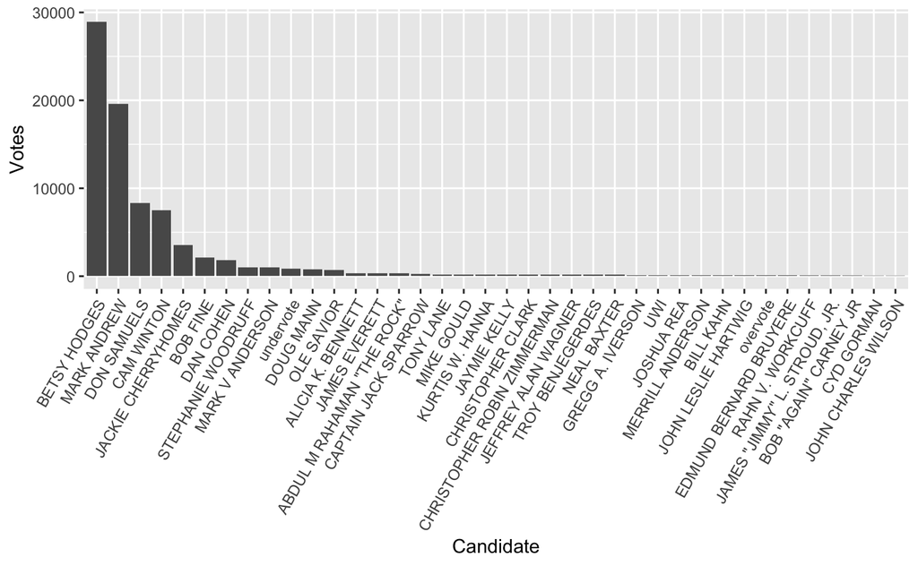

```r
# sorted bar chart
ggplot(data = VoteResults,
       aes(x = reorder(First, desc(votes)), y = votes )) +
       geom_bar(stat = 'identity') +
       theme(axis.text.x = element_text(angle = 60, hjust = 1)) +
       ylab("Votes") +
       xlab("Candidate")
```

This graph reflects the following data table (only part of which is shown):

```r
# we'll get to know these functions better soon
VoteResults %>%
  arrange( desc(votes) ) %>%
  head()
```

| First | votes |
| --- | --- |
| BETSY HODGES | 28935 |
| MARK ANDREW | 19584 |
| DON SAMUELS | 8335 |
| CAM WINTON | 7511 |
| JACKIE CHERRYHOMES | 3524 |
| BOB FINE | 2094 |

Compare the `Minneapolis2013` data table and the wrangled data table printed above.

1. Do they have the same number of cases?
2. Do the cases in the two tables represent the same sort of thing?
3. Do the two tables have any variable(s) in common?
4. How are the two tables are related to one another?

## Why we wrangle

Data wrangling **prepares** the data for analysis.

- convert to tidy form for computing
- prepare glyph-ready data for visualization
- prepare data for modeling (e.g., exploratory, inferential, predictive)

## Different types of functions

- Useful to have consistent language for data wrangling, just as we’ve done for visualization
- Some common function types:
  - **Reduction functions**
  - **Transformation functions**
  - **Data verbs**

**For each type of function, what type of object is required as an input and what type of object is produced as a result?**

- Relevant objects here include
  - scalars
  - variables
  - data frames

## Different types of functions

- **Reduction functions**
  - inputs are **variables**
  - results are **scalar**
  - examples: `sum()`, `mean()`, `n()`
- **Transformation functions**
  - inputs are **variables**;
  - results are **variable**
  - examples: `weight / height`, `log10(population)`, `round(age)`
- **Data verbs**
  - inputs are **data frames**
  - results are **data frames**
  - examples: `summarise()`, `group_by()`

#### Any surprises above?

- `summarise()` as a data verb? Why not a reduction function??

## Let’s use some other reduction functions, transformation functions, and data verbs with the some NFL data

```r
dat.football <- read_tsv(file = "https://raw.githubusercontent.com/ada-lovecraft/ProcessingSketches/master/Bits%20and%20Pieces/Football_Stuff/data/nfl-salaries.tsv")
head(dat.football) #default is first 6 rows and all the columns
```

| PlayerName | Position | Salary | NextSalary | SalaryCap | Team |
| --- | --- | --- | --- | --- | --- |
| Tony Romo | QB | 9000000 | 11500000 | 18905000 | Dallas Cowboys |
| Anthony Spencer | LB | 8800000 | 0 | 8800000 | Dallas Cowboys |
| Jay Ratliff | DE | 4875000 | 0 | 6475000 | Dallas Cowboys |
| Terence Newman (buyout) | CB | 4800000 | 0 | 4800000 | Dallas Cowboys |
| Orlando Scandrick | CB | 4700000 | 0 | 7700000 | Dallas Cowboys |
| DeMarcus Ware | LB | 4500000 | 5500000 | 10303000 | Dallas Cowboys |

```r
head(dat.football, n =10)
```

| PlayerName | Position | Salary | NextSalary | SalaryCap | Team |
| --- | --- | --- | --- | --- | --- |
| Tony Romo | QB | 9000000 | 11500000 | 18905000 | Dallas Cowboys |
| Anthony Spencer | LB | 8800000 | 0 | 8800000 | Dallas Cowboys |
| Jay Ratliff | DE | 4875000 | 0 | 6475000 | Dallas Cowboys |
| Terence Newman (buyout) | CB | 4800000 | 0 | 4800000 | Dallas Cowboys |
| Orlando Scandrick | CB | 4700000 | 0 | 7700000 | Dallas Cowboys |
| DeMarcus Ware | LB | 4500000 | 5500000 | 10303000 | Dallas Cowboys |
| Jason Witten | TE | 3641000 | 0 | 5841000 | Dallas Cowboys |
| Marcus Spears | DE | 2000000 | 2000000 | 2700000 | Dallas Cowboys |
| Kenyon Coleman | DE | 1900000 | 0 | 2245000 | Dallas Cowboys |
| Jason Hatcher | DE | 1500000 | 2000000 | 2100000 | Dallas Cowboys |

```r
dat.football %>%
  slice(1:10)
```

| PlayerName | Position | Salary | NextSalary | SalaryCap | Team |
| --- | --- | --- | --- | --- | --- |
| Tony Romo | QB | 9000000 | 11500000 | 18905000 | Dallas Cowboys |
| Anthony Spencer | LB | 8800000 | 0 | 8800000 | Dallas Cowboys |
| Jay Ratliff | DE | 4875000 | 0 | 6475000 | Dallas Cowboys |
| Terence Newman (buyout) | CB | 4800000 | 0 | 4800000 | Dallas Cowboys |
| Orlando Scandrick | CB | 4700000 | 0 | 7700000 | Dallas Cowboys |
| DeMarcus Ware | LB | 4500000 | 5500000 | 10303000 | Dallas Cowboys |
| Jason Witten | TE | 3641000 | 0 | 5841000 | Dallas Cowboys |
| Marcus Spears | DE | 2000000 | 2000000 | 2700000 | Dallas Cowboys |
| Kenyon Coleman | DE | 1900000 | 0 | 2245000 | Dallas Cowboys |
| Jason Hatcher | DE | 1500000 | 2000000 | 2100000 | Dallas Cowboys |

```r
## Get the dimensions of the data
dim(dat.football)
```

```
[1] 1501    6
```

```r
## Get the column names of the data
colnames(dat.football)
```

```
[1] "PlayerName" "Position"   "Salary"     "NextSalary" "SalaryCap"  "Team"
```

```r
## Get the row names of the data
rownames(dat.football) #meaningless! (most times they will be)
```

[output not shown]

[output cut: 70 more lines]

```r
## Get a summary of the data
## sumamry is not summarize!
summary(dat.football) # gives summary info by column
```

```
  PlayerName          Position             Salary           NextSalary
 Length:1501        Length:1501        Min.   :    2333   Min.   :       0
 Class :character   Class :character   1st Qu.:  490000   1st Qu.:       0
 Mode  :character   Mode  :character   Median :  615000   Median :  555000
                                       Mean   : 1566829   Mean   : 1248008
                                       3rd Qu.: 1700000   3rd Qu.:  900000
                                       Max.   :18000000   Max.   :20000000
   SalaryCap            Team
 Min.   :       0   Length:1501
 1st Qu.:  515946   Class :character
 Median :  770000   Mode  :character
 Mean   : 2171577
 3rd Qu.: 2700000
 Max.   :20250000
```

Now lets look at some `tidyverse` functions.

```r
#Filter
dat.football %>%
  filter(Team == "Denver Broncos")
```

| PlayerName | Position | Salary | NextSalary | SalaryCap | Team |
| --- | --- | --- | --- | --- | --- |
| Peyton Manning | QB | 18000000 | 20000000 | 18000000 | Denver Broncos |
| Elvis Dumervil | DE | 14000000 | 12000000 | 14500000 | Denver Broncos |
| Champ Bailey | CB | 8000000 | 9000000 | 9500000 | Denver Broncos |
| Brian Dawkins | S | 6000000 | 6000000 | 9156000 | Denver Broncos |
| D.J. Williams | LB | 5000000 | 6000000 | 5000000 | Denver Broncos |
| Andre' Goodman | CB | 4620000 | 3960000 | 5580000 | Denver Broncos |
| Ty Warren | DT | 4000000 | 0 | 5250000 | Denver Broncos |
| Chris Kuper | G | 3500000 | 4500000 | 3500000 | Denver Broncos |
| Ryan Clady | T | 3500000 | 0 | 4010000 | Denver Broncos |
| Matt Prater | K | 2665000 | 0 | 2665000 | Denver Broncos |

[output cut: 48 more lines]

```r
#Arrange
dat.football %>%
  arrange(Salary) #lowest to highest
```

| PlayerName | Position | Salary | NextSalary | SalaryCap | Team |
| --- | --- | --- | --- | --- | --- |
| Richard Dickson (buyout) | TE | 2333 | 0 | 2333 | Detroit Lions |
| Kevin Haslam (buyout) | T | 3333 | 0 | 3333 | Jacksonville Jaguars |
| Curtis Painter (buyout) | QB | 22750 | 0 | 22750 | Indianapolis Colts |
| Jon Corto (Buyout) | S | 25000 | 0 | 25000 | Buffalo Bills |
| George Selvie (buyout) | DE | 27976 | 0 | 27976 | St. Louis Rams |
| David Buehler (buyout) | K | 37125 | 0 | 37125 | Dallas Cowboys |
| Markell Carter | DE | 70539 | 0 | 390000 | New England Patriots |
| Morgan Trent (Buyout) | CB | 84000 | 0 | 84000 | Cincinnati Bengals |
| Anthony Herrera (buyout) | G | 100000 | 0 | 100000 | Minnesota Vikings |
| Jordan Todman (buyout) | RB | 128094 | 0 | 128094 | San Diego Chargers |

[output cut: 990 more lines]

```r
dat.football %>%
  arrange(desc(Salary)) #highest to lowest
```

| PlayerName | Position | Salary | NextSalary | SalaryCap | Team |
| --- | --- | --- | --- | --- | --- |
| Peyton Manning | QB | 18000000 | 20000000 | 18000000 | Denver Broncos |
| Drew Brees | QB | 15760000 | 0 | 15760000 | New Orleans Saints |
| Dwight Freeney | DE | 14035000 | 0 | 19035000 | Indianapolis Colts |
| Elvis Dumervil | DE | 14000000 | 12000000 | 14500000 | Denver Broncos |
| Michael Vick | QB | 12500000 | 12500000 | 13900000 | Philadelphia Eagles |
| Sam Bradford | QB | 12000000 | 9000000 | 15594800 | St. Louis Rams |
| Jared Allen | DE | 11619850 | 14280612 | 14203183 | Minnesota Vikings |
| Matthew Stafford | QB | 11500000 | 1200000 | 17258750 | Detroit Lions |
| Matt Ryan | QB | 11500000 | 10000000 | 13000000 | Atlanta Falcons |
| Tamba Hali | DE | 11250000 | 12250000 | 14250000 | Kansas City Chiefs |

[output cut: 990 more lines]

```r
#Select
dat.football %>%
  select(PlayerName, Position)
```

| PlayerName | Position |
| --- | --- |
| Tony Romo | QB |
| Anthony Spencer | LB |
| Jay Ratliff | DE |
| Terence Newman (buyout) | CB |
| Orlando Scandrick | CB |
| DeMarcus Ware | LB |
| Jason Witten | TE |
| Marcus Spears | DE |
| Kenyon Coleman | DE |
| Jason Hatcher | DE |

[output cut: 990 more lines]

```r
#Rename
dat.football %>%
  rename(TeamName = Team)
```

| PlayerName | Position | Salary | NextSalary | SalaryCap | TeamName |
| --- | --- | --- | --- | --- | --- |
| Tony Romo | QB | 9000000 | 11500000 | 18905000 | Dallas Cowboys |
| Anthony Spencer | LB | 8800000 | 0 | 8800000 | Dallas Cowboys |
| Jay Ratliff | DE | 4875000 | 0 | 6475000 | Dallas Cowboys |
| Terence Newman (buyout) | CB | 4800000 | 0 | 4800000 | Dallas Cowboys |
| Orlando Scandrick | CB | 4700000 | 0 | 7700000 | Dallas Cowboys |
| DeMarcus Ware | LB | 4500000 | 5500000 | 10303000 | Dallas Cowboys |
| Jason Witten | TE | 3641000 | 0 | 5841000 | Dallas Cowboys |
| Marcus Spears | DE | 2000000 | 2000000 | 2700000 | Dallas Cowboys |
| Kenyon Coleman | DE | 1900000 | 0 | 2245000 | Dallas Cowboys |
| Jason Hatcher | DE | 1500000 | 2000000 | 2100000 | Dallas Cowboys |

[output cut: 990 more lines]

```r
#Mutate
dat.football %>%
  mutate(PercentOfCap = Salary / SalaryCap * 100)
```

| PlayerName | Position | Salary | NextSalary | SalaryCap | Team | PercentOfCap |
| --- | --- | --- | --- | --- | --- | --- |
| Tony Romo | QB | 9000000 | 11500000 | 18905000 | Dallas Cowboys | 47.60645 |
| Anthony Spencer | LB | 8800000 | 0 | 8800000 | Dallas Cowboys | 100.00000 |
| Jay Ratliff | DE | 4875000 | 0 | 6475000 | Dallas Cowboys | 75.28958 |
| Terence Newman (buyout) | CB | 4800000 | 0 | 4800000 | Dallas Cowboys | 100.00000 |
| Orlando Scandrick | CB | 4700000 | 0 | 7700000 | Dallas Cowboys | 61.03896 |
| DeMarcus Ware | LB | 4500000 | 5500000 | 10303000 | Dallas Cowboys | 43.67660 |
| Jason Witten | TE | 3641000 | 0 | 5841000 | Dallas Cowboys | 62.33522 |
| Marcus Spears | DE | 2000000 | 2000000 | 2700000 | Dallas Cowboys | 74.07407 |
| Kenyon Coleman | DE | 1900000 | 0 | 2245000 | Dallas Cowboys | 84.63252 |
| Jason Hatcher | DE | 1500000 | 2000000 | 2100000 | Dallas Cowboys | 71.42857 |

[output cut: 990 more lines]

```r
#Group
dat.football %>%
  group_by(Team) #doesn't look like it did anything???
```

| PlayerName | Position | Salary | NextSalary | SalaryCap | Team |
| --- | --- | --- | --- | --- | --- |
| Tony Romo | QB | 9000000 | 11500000 | 18905000 | Dallas Cowboys |
| Anthony Spencer | LB | 8800000 | 0 | 8800000 | Dallas Cowboys |
| Jay Ratliff | DE | 4875000 | 0 | 6475000 | Dallas Cowboys |
| Terence Newman (buyout) | CB | 4800000 | 0 | 4800000 | Dallas Cowboys |
| Orlando Scandrick | CB | 4700000 | 0 | 7700000 | Dallas Cowboys |
| DeMarcus Ware | LB | 4500000 | 5500000 | 10303000 | Dallas Cowboys |
| Jason Witten | TE | 3641000 | 0 | 5841000 | Dallas Cowboys |
| Marcus Spears | DE | 2000000 | 2000000 | 2700000 | Dallas Cowboys |
| Kenyon Coleman | DE | 1900000 | 0 | 2245000 | Dallas Cowboys |
| Jason Hatcher | DE | 1500000 | 2000000 | 2100000 | Dallas Cowboys |

[output cut: 990 more lines]

```r
#Summarise
?summarise

dat.football %>%
  summarise(MeanSalary = mean(Salary))
```

| MeanSalary |
| --- |
| 1566829 |

```r
dat.football %>%
  summarize(SdSalary = sd(Salary))
```

| SdSalary |
| --- |
| 2099740 |

```r
dat.football %>%
  group_by(Team) %>%
  summarise(MeanSalary = mean(Salary), .groups = "keep" )
```

| Team | MeanSalary |
| --- | --- |
| Arizona Cardinals | 1594186.0 |
| Atlanta Falcons | 1828406.9 |
| Baltimore Ravens | 2156606.1 |
| Buffalo Bills | 1315185.4 |
| Carolina Panthers | 1353845.5 |
| Chicago Bears | 1758005.6 |
| Cincinnati Bengals | 1283529.3 |
| Cleveland Browns | 1573352.4 |
| Dallas Cowboys | 1480814.0 |
| Denver Broncos | 1683837.3 |

[output cut: 21 more lines]

```r
NA
NA
```

## Exploratory Analysis - Combining it all together

What is the highest salary?

```r
max(dat.football$Salary)
```

[output not shown]

Which player has this salary?

```r
# Method 1 (no tidyverse functions)
max.salary <- max(dat.football$Salary) #get the max salary
row.max.salary <- dat.football$Salary == max.salary
answer.1 <- dat.football$PlayerName[row.max.salary]

#c(1, 2, 3, 4)[c(FALSE, FALSE, TRUE, FALSE)]

# Method 2 (tidyverse functions)
answer.2 <- dat.football %>%
  filter(Salary == max(Salary) ) %>%
  select(PlayerName)

# Method 3 (tidyverse functions)
answer.3 <- dat.football %>%
  arrange(desc(Salary)) %>%
  slice(1) %>%
  select(PlayerName)

## Whats the benefit of using tidyverse functions?
library(utils)
object.size(c(max.salary, row.max.salary, answer.1))
object.size(answer.2)
object.size(answer.3)

944/12304 # used only 7% of the storage space by using tidyverse!
```

[output not shown]

What is the team with the highest paid roster, and what was their total pay? What is the team with the lowest paid roster, and what was their total pay?

```r
Paid <- dat.football %>%
  group_by(Team)%>%
  summarize(PaidRoster = sum(Salary)) %>%
  arrange(desc(PaidRoster))

Paid[1, ] #highest paid
# how many teams are in our data set>

dim(Paid)
length(unique(dat.football$Team))
Paid[31, ]

#Bonus Question, if I said this data was from 2016 what team is missing from our data?
sort(unique(dat.football$Team))
```

[output not shown]

## Pivot wider and Pivot Longer

`pivot_wider()` and `pivot_longer()` are two VERY useful functions in the `tidyverse`. We do not need them this week, but I wanted to introduce them if you want to get ahead.

```r
## Pivot Wider
?pivot_wider

# names_from = new column names
# value_from = values to fill in in the table
us_rent_income
us_rent_income %>%
  pivot_wider(
    names_from = variable,
    values_from = c(estimate, moe)
  )
# is the above table tidy? What is each case?

## Pivot Longer
?pivot_longer
#name_to = new column name that will contain the old column names
#values_to = new column name that will contain the data from the original table
relig_income
relig_income %>%
  pivot_longer(!religion,  # every column but religion
               names_to = "income",
               values_to = "count")
# Is the above table Tidy? What is a case?

world_bank_pop
world_bank_pop %>%
  pivot_longer(!c(country, indicator),
               names_to = "year",
               values_to = "count")
# is the above table tidy? What is a case?
```